# Risk Factor Analysis

## Outcome Variable

**Outcome Variable:** haz

## Predictor Variables

**Intervention Variable:** safeh20

**Adjustment Set:**

- arm
- sex
- W_mage
- meducyrs
- feducyrs
- hhwealth_quart
- hfoodsec
- W_mhtcm
- W_mwtkg
- W_mbmi
- W_nrooms
- W_nchldlt5
- W_parity
- impfloor
- impsan
- delta_W_mage
- delta_meducyrs
- delta_feducyrs
- delta_hhwealth_quart
- delta_hfoodsec
- delta_W_mhtcm
- delta_W_mwtkg
- delta_W_mbmi
- delta_W_nrooms
- delta_W_nchldlt5
- delta_W_parity
- delta_impfloor
- delta_impsan

## Stratifying Variables

The analysis was stratified on these variable(s):

- agecat
- studyid
- country

## Data Summary

| agecat | studyid | country | safeh20 | n_cell | n |
| --- | --- | --- | --- | --- | --- |
| Birth | ki0047075b-MAL-ED | BANGLADESH | 1 | 0 | 213 |
| Birth | ki0047075b-MAL-ED | BANGLADESH | 0 | 213 | 213 |
| Birth | ki0047075b-MAL-ED | BRAZIL | 1 | 0 | 41 |
| Birth | ki0047075b-MAL-ED | BRAZIL | 0 | 41 | 41 |
| Birth | ki0047075b-MAL-ED | INDIA | 1 | 0 | 41 |
| Birth | ki0047075b-MAL-ED | INDIA | 0 | 41 | 41 |
| Birth | ki0047075b-MAL-ED | NEPAL | 1 | 1 | 26 |
| Birth | ki0047075b-MAL-ED | NEPAL | 0 | 25 | 26 |
| Birth | ki0047075b-MAL-ED | PERU | 1 | 9 | 207 |
| Birth | ki0047075b-MAL-ED | PERU | 0 | 198 | 207 |
| Birth | ki0047075b-MAL-ED | SOUTH AFRICA | 1 | 13 | 96 |
| Birth | ki0047075b-MAL-ED | SOUTH AFRICA | 0 | 83 | 96 |
| Birth | ki0047075b-MAL-ED | TANZANIA, UNITED REPUBLIC OF | 1 | 79 | 119 |
| Birth | ki0047075b-MAL-ED | TANZANIA, UNITED REPUBLIC OF | 0 | 40 | 119 |
| Birth | ki1017093-NIH-Birth | BANGLADESH | 1 | 606 | 608 |
| Birth | ki1017093-NIH-Birth | BANGLADESH | 0 | 2 | 608 |
| Birth | ki1017093b-PROVIDE | BANGLADESH | 1 | 45 | 45 |
| Birth | ki1017093b-PROVIDE | BANGLADESH | 0 | 0 | 45 |
| Birth | ki1017093c-NIH-Crypto | BANGLADESH | 1 | 732 | 732 |
| Birth | ki1017093c-NIH-Crypto | BANGLADESH | 0 | 0 | 732 |
| Birth | kiGH5241-JiVitA-3 | BANGLADESH | 1 | 22392 | 22432 |
| Birth | kiGH5241-JiVitA-3 | BANGLADESH | 0 | 40 | 22432 |
| Birth | kiGH5241-JiVitA-4 | BANGLADESH | 1 | 2820 | 2820 |
| Birth | kiGH5241-JiVitA-4 | BANGLADESH | 0 | 0 | 2820 |
| 6 months | ki0047075b-MAL-ED | BANGLADESH | 1 | 0 | 240 |
| 6 months | ki0047075b-MAL-ED | BANGLADESH | 0 | 240 | 240 |
| 6 months | ki0047075b-MAL-ED | BRAZIL | 1 | 0 | 142 |
| 6 months | ki0047075b-MAL-ED | BRAZIL | 0 | 142 | 142 |
| 6 months | ki0047075b-MAL-ED | INDIA | 1 | 0 | 235 |
| 6 months | ki0047075b-MAL-ED | INDIA | 0 | 235 | 235 |

[output cut: 52 more lines]

The following strata were considered:

- agecat: 24 months, studyid: ki0047075b-MAL-ED, country: BANGLADESH
- agecat: 24 months, studyid: ki0047075b-MAL-ED, country: BRAZIL
- agecat: 24 months, studyid: ki0047075b-MAL-ED, country: INDIA
- agecat: 24 months, studyid: ki0047075b-MAL-ED, country: NEPAL
- agecat: 24 months, studyid: ki0047075b-MAL-ED, country: PERU
- agecat: 24 months, studyid: ki0047075b-MAL-ED, country: SOUTH AFRICA
- agecat: 24 months, studyid: ki0047075b-MAL-ED, country: TANZANIA, UNITED REPUBLIC OF
- agecat: 24 months, studyid: ki1017093-NIH-Birth, country: BANGLADESH
- agecat: 24 months, studyid: ki1017093b-PROVIDE, country: BANGLADESH
- agecat: 24 months, studyid: ki1017093c-NIH-Crypto, country: BANGLADESH
- agecat: 24 months, studyid: ki1114097-CONTENT, country: PERU
- agecat: 24 months, studyid: ki1148112-LCNI-5, country: MALAWI
- agecat: 24 months, studyid: kiGH5241-JiVitA-3, country: BANGLADESH
- agecat: 24 months, studyid: kiGH5241-JiVitA-4, country: BANGLADESH
- agecat: 6 months, studyid: ki0047075b-MAL-ED, country: BANGLADESH
- agecat: 6 months, studyid: ki0047075b-MAL-ED, country: BRAZIL
- agecat: 6 months, studyid: ki0047075b-MAL-ED, country: INDIA
- agecat: 6 months, studyid: ki0047075b-MAL-ED, country: NEPAL
- agecat: 6 months, studyid: ki0047075b-MAL-ED, country: PERU
- agecat: 6 months, studyid: ki0047075b-MAL-ED, country: SOUTH AFRICA
- agecat: 6 months, studyid: ki0047075b-MAL-ED, country: TANZANIA, UNITED REPUBLIC OF
- agecat: 6 months, studyid: ki1000304b-SAS-FoodSuppl, country: INDIA
- agecat: 6 months, studyid: ki1017093-NIH-Birth, country: BANGLADESH
- agecat: 6 months, studyid: ki1017093b-PROVIDE, country: BANGLADESH
- agecat: 6 months, studyid: ki1017093c-NIH-Crypto, country: BANGLADESH
- agecat: 6 months, studyid: ki1114097-CONTENT, country: PERU
- agecat: 6 months, studyid: ki1148112-LCNI-5, country: MALAWI
- agecat: 6 months, studyid: kiGH5241-JiVitA-3, country: BANGLADESH
- agecat: 6 months, studyid: kiGH5241-JiVitA-4, country: BANGLADESH
- agecat: Birth, studyid: ki0047075b-MAL-ED, country: BANGLADESH
- agecat: Birth, studyid: ki0047075b-MAL-ED, country: BRAZIL
- agecat: Birth, studyid: ki0047075b-MAL-ED, country: INDIA
- agecat: Birth, studyid: ki0047075b-MAL-ED, country: NEPAL
- agecat: Birth, studyid: ki0047075b-MAL-ED, country: PERU
- agecat: Birth, studyid: ki0047075b-MAL-ED, country: SOUTH AFRICA
- agecat: Birth, studyid: ki0047075b-MAL-ED, country: TANZANIA, UNITED REPUBLIC OF
- agecat: Birth, studyid: ki1017093-NIH-Birth, country: BANGLADESH
- agecat: Birth, studyid: ki1017093b-PROVIDE, country: BANGLADESH
- agecat: Birth, studyid: ki1017093c-NIH-Crypto, country: BANGLADESH
- agecat: Birth, studyid: kiGH5241-JiVitA-3, country: BANGLADESH
- agecat: Birth, studyid: kiGH5241-JiVitA-4, country: BANGLADESH

### Dropped Strata

Some strata were dropped due to rare outcomes:

- agecat: Birth, studyid: ki0047075b-MAL-ED, country: BANGLADESH
- agecat: Birth, studyid: ki0047075b-MAL-ED, country: BRAZIL
- agecat: Birth, studyid: ki0047075b-MAL-ED, country: INDIA
- agecat: Birth, studyid: ki0047075b-MAL-ED, country: NEPAL
- agecat: Birth, studyid: ki1017093-NIH-Birth, country: BANGLADESH
- agecat: Birth, studyid: ki1017093b-PROVIDE, country: BANGLADESH
- agecat: Birth, studyid: ki1017093c-NIH-Crypto, country: BANGLADESH
- agecat: Birth, studyid: kiGH5241-JiVitA-4, country: BANGLADESH
- agecat: 6 months, studyid: ki0047075b-MAL-ED, country: BANGLADESH
- agecat: 6 months, studyid: ki0047075b-MAL-ED, country: BRAZIL
- agecat: 6 months, studyid: ki0047075b-MAL-ED, country: INDIA
- agecat: 6 months, studyid: ki0047075b-MAL-ED, country: NEPAL
- agecat: 6 months, studyid: ki1000304b-SAS-FoodSuppl, country: INDIA
- agecat: 6 months, studyid: ki1017093-NIH-Birth, country: BANGLADESH
- agecat: 6 months, studyid: ki1017093b-PROVIDE, country: BANGLADESH
- agecat: 6 months, studyid: ki1017093c-NIH-Crypto, country: BANGLADESH
- agecat: 6 months, studyid: ki1114097-CONTENT, country: PERU
- agecat: 6 months, studyid: kiGH5241-JiVitA-4, country: BANGLADESH
- agecat: 24 months, studyid: ki0047075b-MAL-ED, country: BANGLADESH
- agecat: 24 months, studyid: ki0047075b-MAL-ED, country: BRAZIL
- agecat: 24 months, studyid: ki0047075b-MAL-ED, country: INDIA
- agecat: 24 months, studyid: ki0047075b-MAL-ED, country: NEPAL
- agecat: 24 months, studyid: ki1017093-NIH-Birth, country: BANGLADESH
- agecat: 24 months, studyid: ki1017093b-PROVIDE, country: BANGLADESH
- agecat: 24 months, studyid: ki1017093c-NIH-Crypto, country: BANGLADESH
- agecat: 24 months, studyid: ki1114097-CONTENT, country: PERU
- agecat: 24 months, studyid: kiGH5241-JiVitA-4, country: BANGLADESH

## Methods Detail

We’re interested in the causal parameters $E[Y_a]$ for all values of $a \in \mathcal{A}$. These parameters represent the mean outcome if, possibly contrary to fact, we intervened to set all units to have $A=a$. Under the randomization and positivity assumptions, these are identified by the statistical parameters $\psi_a=E_W[E_{Y|A,W}(Y|A=a,W)]$. In addition, we’re interested in the mean of $Y$, $E[Y]$ under no intervention (the observed mean). We will estimate these parameters by using SuperLearner to fit the relevant likelihood factors – $E_{Y|A,W}(Y|A=a,W)$ and $p(A=a|W)$, and then updating our likelihood fit using a joint TMLE.

For unadjusted analyses ($W=\{\}$), initial likelihoods were estimated using Lrnr_glm to estimate the simple $E(Y|A)$ and Lrnr_mean to estimate $p(A)$. For adjusted analyses, a small library containing Lrnr_glmnet, Lrnr_xgboost, and Lrnr_mean was used.

Having estimated these parameters, we will then use the delta method to estimate relative risks and attributable risks relative to a prespecified baseline level of $A$.

# Results Detail

## Results Plots

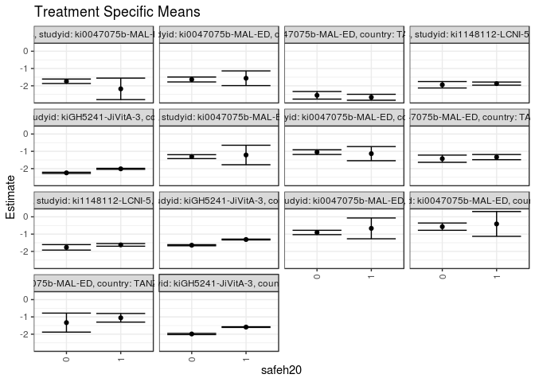

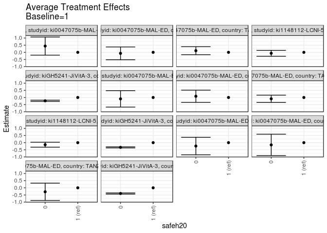

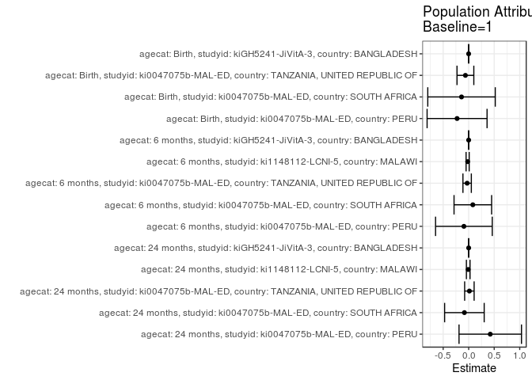

## Results Table

### Parameter: TSM

| agecat | studyid | country | intervention_level | baseline_level | estimate | ci_lower | ci_upper |
| --- | --- | --- | --- | --- | --- | --- | --- |
| Birth | ki0047075b-MAL-ED | PERU | 1 | NA | -0.6677778 | -1.2689426 | -0.0666129 |
| Birth | ki0047075b-MAL-ED | PERU | 0 | NA | -0.9054040 | -1.0308665 | -0.7799416 |
| Birth | ki0047075b-MAL-ED | SOUTH AFRICA | 1 | NA | -0.4120568 | -1.1297963 | 0.3056826 |
| Birth | ki0047075b-MAL-ED | SOUTH AFRICA | 0 | NA | -0.5692542 | -0.7794933 | -0.3590151 |
| Birth | ki0047075b-MAL-ED | TANZANIA, UNITED REPUBLIC OF | 1 | NA | -1.0518000 | -1.3012601 | -0.8023398 |
| Birth | ki0047075b-MAL-ED | TANZANIA, UNITED REPUBLIC OF | 0 | NA | -1.3309086 | -1.8805714 | -0.7812457 |
| Birth | kiGH5241-JiVitA-3 | BANGLADESH | 1 | NA | -1.5889238 | -1.6085903 | -1.5692574 |
| Birth | kiGH5241-JiVitA-3 | BANGLADESH | 0 | NA | -1.9862382 | -2.0207610 | -1.9517154 |
| 6 months | ki0047075b-MAL-ED | PERU | 1 | NA | -1.2128849 | -1.7766636 | -0.6491062 |
| 6 months | ki0047075b-MAL-ED | PERU | 0 | NA | -1.3090043 | -1.4220473 | -1.1959614 |
| 6 months | ki0047075b-MAL-ED | SOUTH AFRICA | 1 | NA | -1.1345190 | -1.5433824 | -0.7256555 |
| 6 months | ki0047075b-MAL-ED | SOUTH AFRICA | 0 | NA | -1.0471707 | -1.1832374 | -0.9111039 |
| 6 months | ki0047075b-MAL-ED | TANZANIA, UNITED REPUBLIC OF | 1 | NA | -1.3354453 | -1.4844762 | -1.1864145 |
| 6 months | ki0047075b-MAL-ED | TANZANIA, UNITED REPUBLIC OF | 0 | NA | -1.4270563 | -1.6355721 | -1.2185404 |
| 6 months | ki1148112-LCNI-5 | MALAWI | 1 | NA | -1.6222536 | -1.6986556 | -1.5458515 |
| 6 months | ki1148112-LCNI-5 | MALAWI | 0 | NA | -1.7659360 | -1.9241446 | -1.6077273 |
| 6 months | kiGH5241-JiVitA-3 | BANGLADESH | 1 | NA | -1.3128323 | -1.3364916 | -1.2891729 |
| 6 months | kiGH5241-JiVitA-3 | BANGLADESH | 0 | NA | -1.6426503 | -1.6730763 | -1.6122244 |
| 24 months | ki0047075b-MAL-ED | PERU | 1 | NA | -2.1757143 | -2.7976265 | -1.5538020 |
| 24 months | ki0047075b-MAL-ED | PERU | 0 | NA | -1.7370699 | -1.8647759 | -1.6093639 |
| 24 months | ki0047075b-MAL-ED | SOUTH AFRICA | 1 | NA | -1.5633084 | -1.9880203 | -1.1385964 |
| 24 months | ki0047075b-MAL-ED | SOUTH AFRICA | 0 | NA | -1.6353151 | -1.7772963 | -1.4933338 |
| 24 months | ki0047075b-MAL-ED | TANZANIA, UNITED REPUBLIC OF | 1 | NA | -2.6626755 | -2.8334733 | -2.4918777 |
| 24 months | ki0047075b-MAL-ED | TANZANIA, UNITED REPUBLIC OF | 0 | NA | -2.5485141 | -2.7684917 | -2.3285365 |
| 24 months | ki1148112-LCNI-5 | MALAWI | 1 | NA | -1.8729285 | -1.9636084 | -1.7822486 |
| 24 months | ki1148112-LCNI-5 | MALAWI | 0 | NA | -1.9408487 | -2.1272698 | -1.7544275 |
| 24 months | kiGH5241-JiVitA-3 | BANGLADESH | 1 | NA | -2.0132889 | -2.0416240 | -1.9849538 |
| 24 months | kiGH5241-JiVitA-3 | BANGLADESH | 0 | NA | -2.2454352 | -2.2801381 | -2.2107324 |

### Parameter: E(Y)

| agecat | studyid | country | intervention_level | baseline_level | estimate | ci_lower | ci_upper |
| --- | --- | --- | --- | --- | --- | --- | --- |
| Birth | ki0047075b-MAL-ED | PERU | NA | NA | -0.8950725 | -1.0180716 | -0.7720734 |
| Birth | ki0047075b-MAL-ED | SOUTH AFRICA | NA | NA | -0.5523958 | -0.7550074 | -0.3497843 |
| Birth | ki0047075b-MAL-ED | TANZANIA, UNITED REPUBLIC OF | NA | NA | -1.1158824 | -1.3283278 | -0.9034369 |
| Birth | kiGH5241-JiVitA-3 | BANGLADESH | NA | NA | -1.5896835 | -1.6089596 | -1.5704074 |
| 6 months | ki0047075b-MAL-ED | PERU | NA | NA | -1.3065026 | -1.4164323 | -1.1965728 |
| 6 months | ki0047075b-MAL-ED | SOUTH AFRICA | NA | NA | -1.0533804 | -1.1834360 | -0.9233247 |
| 6 months | ki0047075b-MAL-ED | TANZANIA, UNITED REPUBLIC OF | NA | NA | -1.3658943 | -1.4882808 | -1.2435078 |
| 6 months | ki1148112-LCNI-5 | MALAWI | NA | NA | -1.6426961 | -1.7120603 | -1.5733318 |
| 6 months | kiGH5241-JiVitA-3 | BANGLADESH | NA | NA | -1.3132090 | -1.3363486 | -1.2900693 |
| 24 months | ki0047075b-MAL-ED | PERU | NA | NA | -1.7529793 | -1.8786399 | -1.6273186 |
| 24 months | ki0047075b-MAL-ED | SOUTH AFRICA | NA | NA | -1.6471273 | -1.7822999 | -1.5119547 |
| 24 months | ki0047075b-MAL-ED | TANZANIA, UNITED REPUBLIC OF | NA | NA | -2.6488498 | -2.7844961 | -2.5132034 |
| 24 months | ki1148112-LCNI-5 | MALAWI | NA | NA | -1.8822648 | -1.9637218 | -1.8008078 |
| 24 months | kiGH5241-JiVitA-3 | BANGLADESH | NA | NA | -2.0135591 | -2.0412422 | -1.9858759 |

### Parameter: ATE

| agecat | studyid | country | intervention_level | baseline_level | estimate | ci_lower | ci_upper |
| --- | --- | --- | --- | --- | --- | --- | --- |
| Birth | ki0047075b-MAL-ED | PERU | 1 | 1 | 0.0000000 | 0.0000000 | 0.0000000 |
| Birth | ki0047075b-MAL-ED | PERU | 0 | 1 | -0.2376263 | -0.8517435 | 0.3764910 |
| Birth | ki0047075b-MAL-ED | SOUTH AFRICA | 1 | 1 | 0.0000000 | 0.0000000 | 0.0000000 |
| Birth | ki0047075b-MAL-ED | SOUTH AFRICA | 0 | 1 | -0.1571974 | -0.9058410 | 0.5914463 |
| Birth | ki0047075b-MAL-ED | TANZANIA, UNITED REPUBLIC OF | 1 | 1 | 0.0000000 | 0.0000000 | 0.0000000 |
| Birth | ki0047075b-MAL-ED | TANZANIA, UNITED REPUBLIC OF | 0 | 1 | -0.2791086 | -0.8838761 | 0.3256589 |
| Birth | kiGH5241-JiVitA-3 | BANGLADESH | 1 | 1 | 0.0000000 | 0.0000000 | 0.0000000 |
| Birth | kiGH5241-JiVitA-3 | BANGLADESH | 0 | 1 | -0.3973144 | -0.4356346 | -0.3589941 |
| 6 months | ki0047075b-MAL-ED | PERU | 1 | 1 | 0.0000000 | 0.0000000 | 0.0000000 |
| 6 months | ki0047075b-MAL-ED | PERU | 0 | 1 | -0.0961194 | -0.6712944 | 0.4790556 |
| 6 months | ki0047075b-MAL-ED | SOUTH AFRICA | 1 | 1 | 0.0000000 | 0.0000000 | 0.0000000 |
| 6 months | ki0047075b-MAL-ED | SOUTH AFRICA | 0 | 1 | 0.0873483 | -0.3428692 | 0.5175658 |
| 6 months | ki0047075b-MAL-ED | TANZANIA, UNITED REPUBLIC OF | 1 | 1 | 0.0000000 | 0.0000000 | 0.0000000 |
| 6 months | ki0047075b-MAL-ED | TANZANIA, UNITED REPUBLIC OF | 0 | 1 | -0.0916109 | -0.3457896 | 0.1625678 |
| 6 months | ki1148112-LCNI-5 | MALAWI | 1 | 1 | 0.0000000 | 0.0000000 | 0.0000000 |
| 6 months | ki1148112-LCNI-5 | MALAWI | 0 | 1 | -0.1436824 | -0.3177748 | 0.0304100 |
| 6 months | kiGH5241-JiVitA-3 | BANGLADESH | 1 | 1 | 0.0000000 | 0.0000000 | 0.0000000 |
| 6 months | kiGH5241-JiVitA-3 | BANGLADESH | 0 | 1 | -0.3298181 | -0.3669542 | -0.2926819 |
| 24 months | ki0047075b-MAL-ED | PERU | 1 | 1 | 0.0000000 | 0.0000000 | 0.0000000 |
| 24 months | ki0047075b-MAL-ED | PERU | 0 | 1 | 0.4386444 | -0.1962443 | 1.0735331 |
| 24 months | ki0047075b-MAL-ED | SOUTH AFRICA | 1 | 1 | 0.0000000 | 0.0000000 | 0.0000000 |
| 24 months | ki0047075b-MAL-ED | SOUTH AFRICA | 0 | 1 | -0.0720067 | -0.5214541 | 0.3774407 |
| 24 months | ki0047075b-MAL-ED | TANZANIA, UNITED REPUBLIC OF | 1 | 1 | 0.0000000 | 0.0000000 | 0.0000000 |
| 24 months | ki0047075b-MAL-ED | TANZANIA, UNITED REPUBLIC OF | 0 | 1 | 0.1141614 | -0.1667107 | 0.3950334 |
| 24 months | ki1148112-LCNI-5 | MALAWI | 1 | 1 | 0.0000000 | 0.0000000 | 0.0000000 |
| 24 months | ki1148112-LCNI-5 | MALAWI | 0 | 1 | -0.0679202 | -0.2754694 | 0.1396291 |
| 24 months | kiGH5241-JiVitA-3 | BANGLADESH | 1 | 1 | 0.0000000 | 0.0000000 | 0.0000000 |
| 24 months | kiGH5241-JiVitA-3 | BANGLADESH | 0 | 1 | -0.2321463 | -0.2759407 | -0.1883519 |

### Parameter: PAR

| agecat | studyid | country | intervention_level | baseline_level | estimate | ci_lower | ci_upper |
| --- | --- | --- | --- | --- | --- | --- | --- |
| Birth | ki0047075b-MAL-ED | PERU | 1 | NA | -0.2272947 | -0.8147485 | 0.3601591 |
| Birth | ki0047075b-MAL-ED | SOUTH AFRICA | 1 | NA | -0.1403390 | -0.8014547 | 0.5207767 |
| Birth | ki0047075b-MAL-ED | TANZANIA, UNITED REPUBLIC OF | 1 | NA | -0.0640824 | -0.2287345 | 0.1005697 |
| Birth | kiGH5241-JiVitA-3 | BANGLADESH | 1 | NA | -0.0007597 | -0.0017906 | 0.0002713 |
| 6 months | ki0047075b-MAL-ED | PERU | 1 | NA | -0.0936177 | -0.6489080 | 0.4616727 |
| 6 months | ki0047075b-MAL-ED | SOUTH AFRICA | 1 | NA | 0.0811386 | -0.2870450 | 0.4493221 |
| 6 months | ki0047075b-MAL-ED | TANZANIA, UNITED REPUBLIC OF | 1 | NA | -0.0304490 | -0.1126715 | 0.0517735 |
| 6 months | ki1148112-LCNI-5 | MALAWI | 1 | NA | -0.0204425 | -0.0510175 | 0.0101325 |
| 6 months | kiGH5241-JiVitA-3 | BANGLADESH | 1 | NA | -0.0003767 | -0.0012860 | 0.0005327 |
| 24 months | ki0047075b-MAL-ED | PERU | 1 | NA | 0.4227350 | -0.1892366 | 1.0347066 |
| 24 months | ki0047075b-MAL-ED | SOUTH AFRICA | 1 | NA | -0.0838189 | -0.4715144 | 0.3038766 |
| 24 months | ki0047075b-MAL-ED | TANZANIA, UNITED REPUBLIC OF | 1 | NA | 0.0138257 | -0.0789651 | 0.1066165 |
| 24 months | ki1148112-LCNI-5 | MALAWI | 1 | NA | -0.0093363 | -0.0448327 | 0.0261601 |
| 24 months | kiGH5241-JiVitA-3 | BANGLADESH | 1 | NA | -0.0002702 | -0.0014172 | 0.0008769 |